# Data analysis with sinusoid of unknown amplitude in known Gaussian noise

The problem you are faced with is detecting and characterizing a sinusoid in Gaussian noise. This is a standard and simple problem in data analysis that will give you a flavor of the data analysis problems and techniques used in real PTA data analysis. In fact, nearly the entire GW detection problem is framed in this way: Is there a detectable GW (be it stochastic, continuous, or burst) present in the puslar timing residual data? The challenge is coming up with robust and efficient analysis methods that take into account all of the intracacies of real puslar timing data.  
Dealing with real or simulated PTA data will only cause additional complications and will deter you from learning the basics of data analysis. In this activity you will explore both frequentist and Bayesian techniques for parameter estimation, detection, and setting upper limits.  
We assume that the data $d$ is composed of a signal $s$ plus additive white gaussian noise $n$, that is $d=s+n.$ Since $n$ is assumed to be white and Gaussian, its probability distribution is a product of Gaussians $p(n)=\frac{1}{\sqrt{2 \pi \sigma^2}}\prod_i\exp\left(-\frac{n_i^2}{2\sigma^2}\right),$ where $n_i$ is the noise at time $t_i$ and $\sigma$ is the standard deviation of the noise. We can now write this in terms of the data using $n=d-s$, therefore the likelihood function for the data given the signal parameters, $\lambda$ is $p(d|\lambda)=\frac{1}{\sqrt{2 \pi \sigma^2}}\prod_i\exp\left(-\frac{(d_i-s_i(\lambda))^2}{2\sigma^2}\right).$ For our purposes we will deal with the natural log of the likelihood ratio. The likelihood ratio is the likelihood function above divided by the likelihood that the signal is pure noise (i.e, remove the signal $s$ from the model). We will also introduce a new notation and write the log-likelihood ratio $\log\Lambda=(d|s)-\frac{1}{2}(s|s),$ where the inner product of two timeseries $x$ and $y$, for example, is $(x|y)=\sum_i x_iy_i/\sigma^2$. In our case the signal $s$ is just a sinusoid, $s(t,A,f) = A\sin(2\pi ft)$. For simplicity we will assume that we know the frequency (or that we are doing a "target" search for a certain frequency) of the sinusoid and the only unknown parameter is the amplitude.  
Your first exercise will be to create a simulated dataset with white noise and a small sinusoid.  
Good luck!

```python
from __future__ import division
import numpy as np
import matplotlib.pyplot as plt
import worksheet_utils as wu
from scipy.interpolate import interp1d
```

## Derving the log-likelihod ratio

Above we have written down the log of the likehood ratio which will be used throughout this entire worksheet. To get yourself familiar with the notation, derive the log-likelihood ratio defined above.  
*Hint*: It will be easier to take the logarithm of each likelihood function first and then take the difference (i.e., $\log(A/B)-\log(A)-\log(B)$).

## Simulating the data set.

Create a 5 year timeseries of 130 points using `numpy` function **`linspace()`** beginning at 0. Then, use the **`simData()`** function from `worksheet_utils` to simulate some fake data with a standard devitaion of 100 ns and a signal with amplitude 70 ns and frequency of $10^{-8}$ Hz.  
Then use the `matplotlib` function **`plot()`** to plot the data vs. time and be sure to label the axes. Next, create a separate dataset with no noise by calling the **`signal()`** function from `worksheet_utils` in order to plot just the signal on top of the signal+noise dataset.

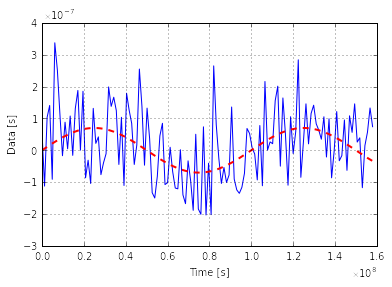

```python
# simulated data
freq = 1e-8
sigma = 1e-7
t = np.linspace(0, 3.16e7*5, 130)
A = 7e-8

# call function to simulate data
data = wu.simData(t, A, freq, sigma)

# can also get signal individually
sig = wu.signal(t, A, freq)

# plot
plt.plot(t, data)
plt.plot(t, sig, lw=2, color='r', ls='--')
plt.xlabel('Time [s]')
plt.ylabel('Data [s]')
plt.grid()
```

## Parameter Estimation: Estimating the Amplitude

In frequentist statistics, one is interested in defining some estimator for the true signal parameters. A common way to do this is to find the parameters that maximize the likelihood. These are known as Maximum Likelihood Estimators (MLEs). One can then place confidence intervals on the parameter of interest through the *Neyman method*: define some statistic $x$ that is a function of the data $d$ (for example the MLE of the unknown signal parameters). Because $x$ is derived from $d$, the probability distribution (likelihood) $p(d|\lambda)$ can be re-expressed as a probability distribution $p(x|\lambda)$. Then, for each value of $\lambda$, we produce an interval $(x_1,x_2)$ such that $\alpha = \int_{x_1}^{x_2}dx\,\, p(x|\lambda)$ The intervals that depend on $\lambda$ define a belt in the $\lambda-x$ plane and for any *observed* value of $x$ in the experiment, the confidence interval on $\lambda$ constitutes the values of $\lambda$ that exist on the belt at that fixed value of $x$. (See additional handout for more details)  
In Bayesian statistics, one is interested finding the probability distribution function for the unknown parameters given that we have some observed data. To get a point estimate of the unkwnown parameters we may use the *maximum a-posteriori* (MAP) parameters, that is, the maximum of the posterior probability distribution. A credible interval (Bayesian version of confidence intervals) can be constructed directly from the posterior distribution $p(\lambda|d)$ as $\alpha = \int_{\lambda_1}^{\lambda_2}d\lambda\,\, p(\lambda|d),$ where $\lambda_1$ and $\lambda_2$ defined the lower and upper bounds on our parameter $\lambda$.

### 2.1 MLE for the amplitude

As written above, the log-likelihood ratio is $\log\Lambda=(d|s)-\frac{1}{2}(s|s).$ If we let $s(t)=A\sin(2\pi f t)$ and $\tilde{s}(t)=\sin(2\pi f t)$, then $s(t)=A\tilde{s}(t)$. Re-writing the log-likehood ratio, we obtain $\log\Lambda=A(d|\tilde{s})-\frac{A^2}{2}(\tilde{s}|\tilde{s}).$ We can now maximize the likehood function over the unknown amplitude, $A$, as follows $0 = \frac{\partial \log\Lambda}{\partial A} = (d|\tilde{s}) -\hat{A}(\tilde{s}|\tilde{s}),$ where $\hat{A}$ is the MLE for $A$. Solving for $\hat{A}$, we obtain $\hat{A}=\frac{(d|\tilde{s})}{(\tilde{s}|\tilde{s})}.$ The variance on the maximum likelihood estimator is then $\sigma_{\hat{A}}^2 = \langle \hat{A}\hat{A} \rangle -\langle \hat{A} \rangle^2 = \frac{1}{(\tilde{s}|\tilde{s})},$ where $\langle \rangle$ denotes the *expectation value* or average over many realizations of data.

1. Write a function that reads in the data, the time samples, the frequency of the sine wave and the standard deviation of the noise as arguments and outputs the MLE and standard deviation of $A$. *Hint:* Look at the `worksheet_utils` package to figure out what functions you may need.  
   For intermediate/expert level: Derive the variance of $\hat{A}$. *Hint:* $\langle (n|\tilde{s}) \rangle=0$ and $\langle (n|\tilde{s})(n|\tilde{s}) \rangle=(\tilde{s}|\tilde{s})$.
2. Use this function to compute $\hat{A}$ for our simulated data set.
3. Does the answer you get make sense? What is the percent error?

```python
#  maximum likelihood estimator for A
def maxLikeA(data, t, f, sigma):
    sig = wu.signal(t, 1, f)
    return wu.innerProduct(data, sig, sigma)/wu.innerProduct(sig, sig, sigma), np.sqrt(1/wu.innerProduct(sig, sig, sigma))
```

```python
Ahat, stdAhat = maxLikeA(data, t, freq, sigma)
print 'MLE for A = {0} +/ {1}'.format(Ahat, stdAhat)
print 'True value of A = {0}'.format(A)
```

```
MLE for A = 7.39367922775e-08 +/ 1.27124648726e-08
True value of A = 7e-08
```

### 2.2 Posterior distribution for the amplitude

1. Write a function that reads in the data, the time samples, the amplitude of the sine wave, the frequency of the sine wave and the standard deviation of the noise and returns the log-likelihood ratio.
2. Create a vector of trial amplitudes in the range $[0, 5\times 10^{-7}]$ with length 1000 using the **`np.linspace()`** function. You can play around with the length of the array and the ranges once you have done this once.
3. Loop over these amplitudes and compute the log-posterior for each one and store it in an array. Here we will use a uniform prior on $A$ which means that the likelihood and the posterior are identical except for a normalizing constant which is not important here. The posterior is then $\log\,p(A|d) \propto \log\Lambda(d|A) + \log p(A),$ where p(A) is the prior.
4. This prior must be normalized to 1, so if our prior is uniform in $A$ then it is the save for every value of $A$, thus $p(A)=C$, where $C$ is a constant. Integrate this uniform prior to determine the normalization constant (i.e., use $\int p(A)dA=1$ to find the value of $C$).
5. Use the **`plt.plot()`** function to plot the posterior vs. the Amplitude Array.
6. Determine the MAP value of $A$ by using the **`np.argmax()`** function to find the array index of the maximum posterior value. You can then use this array index to find the corresponding value of $A$ from the vector of trial amplitudes that you created in step 2.
7. Determine the standard deviation of $A$. *Hint:* recall that the statistical definition of variance on a parameter $x$ whose pdf is $p(x)$ is $\sigma^2_x=\langle x^2 \rangle - \langle x \rangle^2 = \int dx \, x^2\,p(x) - \left(\int dx\, x\, p(x)\right)^2$
8. Plot the likelihood vs $A$. Plot a vertical line denoting the true value of $A$ with the **`plt.axvline()`** function. Also, use the **`plt.axvspan()`** with the *alpha* argument to plot a shaded region denoting the standard deviation of $A$.

```python
# likelihood function
def LogLikelihood(data, t, A, f, sigma):
    sig = wu.signal(t, A, f)
    return wu.innerProduct(data, sig, sigma) - 0.5 * wu.innerProduct(sig, sig, sigma)
```

```
MAP value for A = 7.40740740741e-08 +/ 1.27124642782e-08
True value of A = 7e-08
```

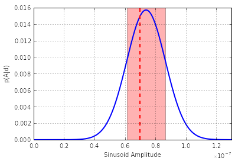

```python
N = 1000
Amps = np.linspace(0, 5e-7, N)
llike = np.zeros(N)
for ii in range(N):
    llike[ii] = LogLikelihood(data, t, Amps[ii], freq, sigma)

post = np.exp(llike) / (Amps.max()-Amps.min())
mapA = Amps[np.argmax(post)]
p = post/post.sum()
stdA = np.sqrt(np.sum(Amps**2*p) - np.sum(Amps*p)**2)
print 'MAP value for A = {0} +/ {1}'.format(mapA, stdA)
print 'True value of A = {0}'.format(A)

plt.plot(Amps, p, lw=2)
plt.axvline(A, color='r', lw=2, ls='--')
plt.axvspan(mapA-stdA,mapA+stdA, facecolor='r',alpha=0.3)
plt.grid()
plt.xlim(0, 1.3e-7)
plt.xlabel('Sinusoid Amplitude')
plt.ylabel('p(A|d)')
```

#### 2.2.1: Gaussian prior distribution on $A$

It is often the case in data analysis where we have some additional prior information about our problem before conducting the experiment. In the Bayesian framework we incorporate this additional information into the prior probability distribution. The data (via the likelihood function) is then used to update our prior knowledge. If our data is *informative* then the posterior distribution will be different then the prior distribution. On the other hand, if our posterior results in distribution that is identical to the prior then our data is not informative.  
To illustrate this, we will assume that through some other experiment, or from some theoretical prediction, we have some prior knowledge of the amplitude of the sine wave in our data. We will model this as a gaussian prior with the mean the true value that we used to create the data and some standard deviation $p(A)=\frac{1}{\sqrt{2\pi\sigma_A^2}}\exp\left(-\frac{(A-A_{\rm true})^2}{2\sigma_A^2}\right)$

1. Let the fractional uncertainty on $A$ be 25%, that is $\sigma_A=0.25\times A$. Use this information in the gaussian prior and repeat the steps from exercise 2.2. You will need to create an extra array to store the prior function when conducting the for loop. When constructing the posterior, remember to multiply the likelihood by the prior.
2. Make sure that the posterior and prior both are both normalized and plot the posterior and the prior vs. A. Is the data informative?
3. Repeat this exercise for $\sigma_A=0.05\times A$.

```
MAP value for A = 7.30730730731e-08 +/ 1.13079109852e-08
True value of A = 7e-08
```

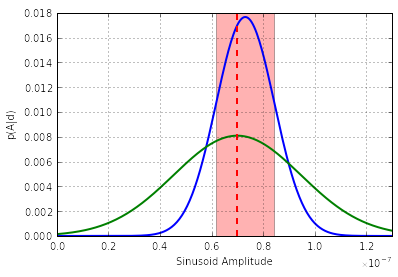

```python
N = 1000
Amps = np.linspace(0, 5e-7, N)
llike2 = np.zeros(N)
logpr2 = np.zeros(N)
sigma_A = A * 0.25
for ii in range(N):
    llike2[ii] = LogLikelihood(data, t, Amps[ii], freq, sigma)
    logpr2[ii] = - 0.5*(np.log(2*np.pi*sigma_A**2) + (Amps[ii]-A)**2/2/sigma_A**2)

post2 = np.exp(llike2+logpr2)
mapA = Amps[np.argmax(post2)]
p2 = post2/post2.sum()
pr = np.exp(logpr2)
pr /= pr.sum()
stdA = np.sqrt(np.sum(Amps**2*p2) - np.sum(Amps*p2)**2)
print 'MAP value for A = {0} +/ {1}'.format(mapA, stdA)
print 'True value of A = {0}'.format(A)

plt.plot(Amps, p2, lw=2)
plt.plot(Amps, pr, lw=2, color='g')

plt.axvline(A, color='r', lw=2, ls='--')
plt.axvspan(mapA-stdA,mapA+stdA, facecolor='r',alpha=0.3)
plt.grid()
plt.xlim(0, 1.3e-7)
plt.xlabel('Sinusoid Amplitude')
plt.ylabel('p(A|d)')
```

```
MAP value for A = 7.05705705706e-08 +/ 4.61245062512e-09
True value of A = 7e-08
```

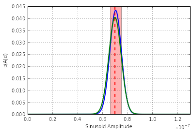

```python
N = 1000
Amps = np.linspace(0, 5e-7, N)
llike2 = np.zeros(N)
logpr2 = np.zeros(N)
sigma_A = A * 0.05
for ii in range(N):
    llike2[ii] = LogLikelihood(data, t, Amps[ii], freq, sigma)
    logpr2[ii] = - 0.5*(np.log(2*np.pi*sigma_A**2) + (Amps[ii]-A)**2/2/sigma_A**2)

post2 = np.exp(llike2+logpr2)
mapA = Amps[np.argmax(post2)]
p2 = post2/post2.sum()
pr = np.exp(logpr2)
pr /= pr.sum()
stdA = np.sqrt(np.sum(Amps**2*p2) - np.sum(Amps*p2)**2)
print 'MAP value for A = {0} +/ {1}'.format(mapA, stdA)
print 'True value of A = {0}'.format(A)

plt.plot(Amps, p2, lw=2)
plt.plot(Amps, pr, lw=2, color='g')

plt.axvline(A, color='r', lw=2, ls='--')
plt.axvspan(mapA-stdA,mapA+stdA, facecolor='r',alpha=0.3)
plt.grid()
plt.xlim(0, 1.3e-7)
plt.xlabel('Sinusoid Amplitude')
plt.ylabel('p(A|d)')
```

### 2.3 Frequentist Confidence Interval on Amplitude Parameter

As we show above, contructing a frequentist confidence interval involves simulating several realizations of data with different values of the sinusoid amplitude. Here we will construct a function to do just that.

1. Create a vector of trial amplitudes in the range $[1\times 10^{-8}, 3\times 10^{-7}]$ with length 100 using the **`linspace()`** function.
2. Loop over these amplitudes as above but now add a second inner loop to simulate different *realizations* of the data. Use **`simData()`** function to simulate the new data. For each amplitude do 1000 realizations of data with that amplitude. (See code block below for hints)
3. The goal here is to compute the MLE for $A$ for each realization of data. For a given amplitude, compute $\hat{A}$ for each data realization using your function from exercise 2.1 and store it in an array. Then use the **`confinterval()`** function from `worksheet_utils` to define the upper and lower 1-sigma bounds on the distribution of $\hat{A}$ for a given value of $A$. Store these 1-sigma lower and upper bounds in arrays. This will create the band through the $A$-$\hat{A}$ space as we saw in the talk. (See code block below for hints)
4. After you have looped over all values of the amplitude. Use the [**`interp1d()`**](http://docs.scipy.org/doc/scipy/reference/tutorial/interpolate.html) function to interpolate the 1-sigma upper and lower bounds on $\hat{A}$ for each value of $A$. This way we create an interpolating function so that we can evaluate the confidence interval on $A$ from our confidence belt and our measurement of $\hat{A}$.
5. Plot the confidence band (i.e., the injected amplitude vs the 1-sigma upper and lower bounds on $\hat{A}$.) as well as a vertical line denoting the measured value of $\hat{A}$ and a shaded area using the **`plt.axhspan()`** function to denote the confidence interval on $A$.

```python
# number of amplitudes
N = 100
Amps = np.linspace(1e-8, 3e-7, N)

# number of realizations
Nreal = 1000

# loop over amplitudes
xmin = np.zeros(N)
xmax = np.zeros(N)
for ii in range(N):
    testAmp = Amps[ii]

    # loop over realizations
    testAhat = np.zeros(Nreal)
    for jj in range(Nreal):

        # simulate data
        newx = wu.simData(t, testAmp, freq, sigma)
        testAhat[jj], tmp = maxLikeA(newx, t, freq, sigma)

    # 1-sigma confidence levels on Ahat
    xmin[ii], xmax[ii] = wu.confinterval(testAhat, sigma=0.68)
```

```
1-sigma upper and lower bounds on A: 6.19309940398e-08 8.859808199e-08
1-sigma upper and lower bounds on Ahat: 6.12243274049e-08 8.66492571501e-08
```

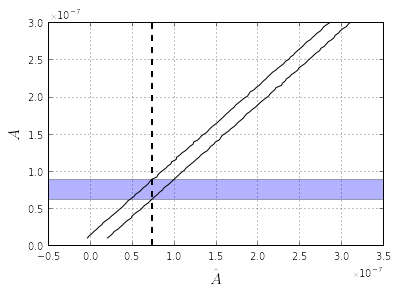

```python
# interpolate to get inverse function for the injected amplitude
# as a function of the confidence regions on Ahat
interplow = interp1d(xmax, Amps)
interphigh = interp1d(xmin, Amps)

plt.plot(xmin, Amps, 'k')
plt.plot(xmax, Amps, 'k')
plt.axvline(Ahat, lw=2, color='k', ls='--')
plt.axhspan(interplow(Ahat), interphigh(Ahat), alpha=0.3)
plt.grid()
plt.xlabel(r'$\hat{A}$', fontsize=16)
plt.ylabel(r'$A$', fontsize=16)

print '1-sigma upper and lower bounds on A: {0} {1}'.format(interplow(Ahat), interphigh(Ahat))
print '1-sigma upper and lower bounds on Ahat: {0} {1}'.format(Ahat-stdAhat, Ahat+stdAhat )
```

### 2.4 Bayesian Credible Interval on Amplitude Parameter

As was discussed in the talk and have shown above, Bayesian credible intervals use the likelihood function directly to measure our confidence, or degree of belief in our measurement of the Amplitude parameter. In practice, this is much less complicated than constructing frequentist confidence intervals. However in more complex data analysis problems with many unknown parameters, just constructing the full likelihood function is very difficult or at least computatinally demanding.

1. Repeat steps 1-3 from exercise 2.2 to construct the likelihood function for $A$.
2. Write down an algorithm for computing the Bayesian credible region. You do not have to write actual code here unless you feel comfortable. Simply think about how you would set up the problem. *Hint:* Remember, the desired integral is  
   $\alpha = \int_{\lambda_1}^{\lambda_2}d\lambda\,\, p(\lambda|d)$ but it can be re-written as  
   $\frac{1-\alpha}{2} = \int_{-\infty}^{\lambda_1}d\lambda\,\, p(\lambda|d)$  
   and  
   $\frac{1+\alpha}{2} = \int^{\infty}_{\lambda_2}d\lambda\,\, p(\lambda|d)$
3. Use the pre-made function **`confinterval_like()`** to construct the 1-sigma upper and lower bounds on $A$.
4. Plot the likelihood function vs. $A$ along with the 1-sigma upper and lower bounds, again using the **`plt.plot()`** and **`plt.axvline()`** functions.

```
1-sigma upper and lower bounds on A: 6.10610610611e-08 8.65865865866e-08
True value of A = 7e-08
```

[figure not shown]

```python
N = 1000
Amps = np.linspace(0, 5e-7, N)
llike = np.zeros(N)
for ii in range(N):
    llike[ii] = LogLikelihood(data, t, Amps[ii], freq, sigma)

like = np.exp(llike)
xmin, xmax = wu.confinterval_like(like, Amps)
print '1-sigma upper and lower bounds on A: {0} {1}'.format(xmin, xmax)
print 'True value of A = {0}'.format(A)

xmin, xmax = wu.confinterval_like(like, Amps)

plt.plot(Amps, like, lw=2)
plt.axvline(A, color='r', lw=2, ls='--')
plt.axvspan(xmin, xmax, facecolor='r',alpha=0.3)

plt.grid()
plt.xlim(0, 1.3e-7)
plt.xlabel('Sinusoid Amplitude')
plt.ylabel('p(A|d)')
```

## Hypothesis Testing: Detecting the Signal

Above, when performing parameter estimation we have taken for granted that there was an *detectable* signal in the data. Now we turn to the problem of detection, that is, how can we confidently say that there truly is a signal in the data. In the frequentist framework, detection significance is usually based on the false alarm probability (sometimes referred to as FAP, I know hilarious right?), that is, the probability that we would (falsely) claim a detection when that data consists of only noise. Henceforth, we refer to this noise only case as the *null hypothesis* and we denote it symbolically as $H_0$. On the other hand we refer to the case where the data does contain a signal as the *signal hypythesis* and we denote it symbolically as $H_1$. In the Bayesian framework, we actually compute the *evidence* for the signal and null hypotheses and compare them via the Bayes factor.

In this next section, we will apply these techniques to our simple problem of the sinusoid with unknown amplitude.

### 3.1 Frequentist Hypothesis Testing

The false alarm probability is defined as  
${\rm FAP} = \int_{\hat x}^{\infty} dx\,\, p(x|\lambda,H_0),$  
where $\hat{x}$ is our measured test statistic, $\lambda$ is the parameter of interest, and $p(x|\lambda,H_0)$ is the pdf of $x$ under the null hypothesis. The dependence on the actual data, comes in the value of $\hat{x}$. Essentially what we are doing is we are testing whether our point extimate of $x$ is consistent with a value of $x$ that we would measure if the data contains only noise. So to claim a detection, we want to reject the null hypothesis, that is, we want $\hat{x}$ to be *inconsistent* with the distribution of $x$ under the null hypothesis and the false alarm probability quantifies that inconsistency.

The value of the false alarm probability that one requires for detection is completely problem dependent. In some cases we would be ok with a value of 5% (i.e., we make a false detection 5% of the time). For example, many of the social sciences use this value. However, for our purposes we want to be much more confident so we will require $FAP < 10^{-4}$ for a detection, that is, there is a 1 in 10,000 chance that we have made a false detection. It is very important to note here that just because we can rule out the null hypothesis with $1-FAP$ confidence, does *not* mean that the signal hypothesis is true with $1-FAP$ confidence. In fact, frequentist detection methods make no statetments about our confidence in the signal model itself, only that a measurement made under the signal hypothesis is inconsistent with the null hypothesis at the $1-FAP$ level.

Now we want to set the value of $\hat{x}$ that would be required for us to have $FAP=10^{-4}$.

1. First, we want to construct our detection statistic. The [Neyman-Pearson lemma](http://en.wikipedia.org/wiki/Neyman–Pearson_lemma) states that the optimal detection statistic is the likelihood ratio. Use our expression for the log-likelihood ratio and $\hat{A}$ from exercise 2.1 to construct the maximum likelihood ratio. *Hint:* you should get  
   $\log \Lambda_{\rm max} = \frac{1}{2}\frac{(d|\tilde s)^2}{(\tilde s|\tilde s)}$
2. As we did for the likelihood ratio. Write a function that reads in the data, the time samples, the frequency of the sine wave and the standard deviation of the noise and returns the maximized log-likelihood ratio.
3. Now we want to construct the pdf of the maximum log-likelihood ratio under the null hypothesis. As we did in exercise 2.3, we want to loop over many realizations of data and compute the max log-likelihood ratio, only this time we simulate only noise. Simulate 100000 realizations of data and store the maximum log-likelihood values in an array and histogram the results with 50 bins using the **`plt.hist()`** function.
4. Now that we have the distribution $p(x|\lambda,H_0)$, we want to determine the value of $\hat{x}=\hat{x}_{\rm thresh}$ that will give a false alarm probability of $10^{-4}$. We have already build all of the machinery we require to determine $\hat{x}_{\rm thresh}$. *Hint:* If we re-write the FAP integral, we can use the **`confinterval()`** function with the argument onesided=True. Please ask for help if you are stuck here.  
   Expert level: This distribution can be computed analytically. Do you know what it is?
5. Use our original data with a signal to determine if we have made a detection.

```python
# maximum likelihood function
def maxLogLikelihood(data, t, f, sigma):
    sig = wu.signal(t, 1, f)
    return wu.innerProduct(data, sig, sigma)**2 / wu.innerProduct(sig, sig, sigma)
```

```python
# number of realizations
Nreal = 100000

# loop over realizations
maxLike0 = np.zeros(Nreal)
for jj in range(Nreal):

    # simulate data
    newx = wu.simData(t, 0, freq, sigma)
    maxLike0[jj] = maxLogLikelihood(newx, t, freq, sigma)
```

```
Threshold for detection = 14.6442121491
Maximum likelihood ratio for real data: 33.8268593847
```

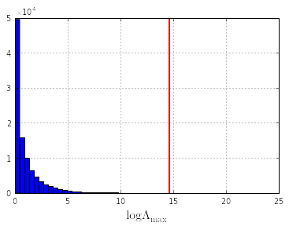

```python
plt.hist(maxLike0, 50)

FAP=1e-4
tmp, thresh = wu.confinterval(maxLike0, onesided=True, sigma=1-FAP)

plt.axvline(thresh, lw=2, color='r')
plt.xlabel(r'$\log\Lambda_{\rm max}$', fontsize=16)
plt.grid()

print 'Threshold for detection = {0}'.format(thresh)

# compute the maximum log likelihood ratio for the "real" data
maxLike = maxLogLikelihood(data, t, freq, sigma)
print 'Maximum likelihood ratio for real data: {0}'.format(maxLike)
```

```python
from scipy.stats import chi2

# the distribution is a chi-squared distribution with 1 degree of freedom
rv = chi2(1)
x = np.linspace(0.1, maxLike0.max(), 100000)

plt.plot(x, rv.pdf(x), lw=2, color='r')

ifunc = interp1d(rv.cdf(x), x)

print ifunc(1-1e-4)
plt.hist(maxLike0, 50, normed=True)

#log(1e-4)
```

[output not shown]

```
15.1367052298
```

### 3.2 Bayesian Hypothesis Testing

When condisering Bayesian parameter estimation, we used Bayes theorem for a *single* hypothesis. We now use the more general form of Bayes theorem:  
$p(\lambda,H|d) = \frac{p(d|\lambda,H)p(\lambda,H)}{p(d)},$ where $p(\lambda,H|d)$ is the probability of the joint posterior of parameters and the hypotheses, $p(d|\lambda,H)$ is the likelihood of the data given a set of parameters and hypotheses, $p(\lambda,H)=p(\lambda|H)p(H)$ is the prior probability on the parameters and hypotheses and $p(d)$ is the probability of the data itself, also known as the evidence. Here we are interested in the evidence:  
$p(d)=\sum_i\int d\lambda_i\,p(d|\lambda_i,H_i)p(\lambda_i|H_i)p(H_i)= \sum_i p(d|H_i)p(H_i)$ which is the sum of the marginal likelihoods for different Hypotheses. In some cases, there may be many possible hypotheses, but it is always possible to compare different ones. In our case we want to *directly* calculate the evidence for hypotheses, $H_1$ and $H_0$. The bayes factor is defined as the ratio of two marginal likelihoods  
$B_{10} = \frac{p(d|H_1)}{p(d|H_0)}.$  
In large parameter spaces, this is notoriously hard to calculate; however, in our case it is trivial since our null hypothesis model has no parameters and our signal model only has 1 parameter we have  
$B_{10}=\int dA\,\, \Lambda(A|d)p(A)$  
where $\Lambda(A|d)$ is just the likelihood ratio defined above and $p(A)$ is the prior on $A$, which we take to be constant. For our calculation, we will need to include the prior even though it is a constant. You can analytically find the normalizing constant by integrating $p(A)=C$ over the range of $A$ (which is $[0,5\times10^{-7}]$ if using the same as exercise 2.2) and setting it equal to 1. That is, we require  
$\int dA\,\, p(A) = 1$

1. Loop over 1000 amplitude values and compute the log likelihood just like in exercise 2.2. Once you have the log-likelihood ratio at each amplitude value you can exponentiate it to obtain the likelihood itself.
2. Use the likelihood values to compute the bayes factor. Remember we can just use a block integral  
   $\int dA\,\, \Lambda(A|d) \approx \sum_i\Lambda(A_i|d) \Delta A.$  
   The value of the Bayes factor that is normally considered decisive evidence for model $H_1$ over model $H_0$ is 100. This values comes from the so-called [Jeffreys' scale](http://en.wikipedia.org/wiki/Bayes_factor#Interpretation). For our purposes here we will follow this scale but in real data analysis applications is is an open problem as to which value one would truly consider decisive, say for claiming the detection of GWs. One could implement a hybrid frequentist-Bayesian method where the Bayes factor is used as our test statistic and we can set corresponding FAPs and thresholds for detection.

```python
N = 1000
Amps = np.linspace(0, 5e-7, N)
dA = Amps[1]-Amps[0]
llike = np.zeros(N)
for ii in range(N):
    llike[ii] = LogLikelihood(data, t, Amps[ii], freq, sigma)

like = np.exp(llike)

# bayes factor
B = np.sum(like)/Amps.max()*dA
print 'Bayes factor = {0}'.format(B)
```

[output not shown]

#### 3.2.1 Occam Penalty

In hypothesis testing we generally want to choose the simplest model if it provides a good fit to the data. In essence, we need to weigh the "goodnes of fit" versus the simplicity of the model. For example, we could use a free parameter for every data point, then our model would fit the data perfectly but this model would have hundreds of parameters, versus just one for our sinusoid model. The bayes factor automatically incorporates this parsimony through the integration of the posterior, which contains our prior distribution.

1. We can see this automatic parsimony by choosing a larger prior range on $A$ in the above calculation of the Bayes factor. Repeat the calculation but now create the amplitude vector going up to $5\times 10^{-6}$. *Hint:* Remember to recalculate the normalization of the prior.

```python
N = 1000
Amps = np.linspace(0, 5e-6, N)
dA = Amps[1]-Amps[0]
llike = np.zeros(N)
for ii in range(N):
    llike[ii] = LogLikelihood(data, t, Amps[ii], freq, sigma)

like = np.exp(llike)

# bayes factor
B = np.sum(like)/Amps.max()*dA
print 'Bayes factor = {0}'.format(B)
```

[output not shown]